# Data Analysis Replication

# **Data Analysis Replication**

#### Article:

Whittaker, B. A., Nolet-Mulholland, L., Nevoit, A., Yun, D., Lambert, C. T., Blunk, S. C., & Guillette, L. M. (2023). Zebra finches have style: Nest morphology is repeatable and associated with experience. *iScience*, *26*(11), 108194. https://doi.org/10.1016/j.isci.2023.108194

#### Introduction:

In this article, the authors looked for repeatability in zebra finch nest construction. Forty captive zebra finches (20 different-sex pairs) had the opportunity to build four nests out of coconut fiber. In an Experimental group, the birds built five nests out of white string before moving on to building nests from coconut fiber, so they had general experience with nest construction. Birds in the Control group did not get prior practice. The completed nests were photographed from standard distances and angles, and landmarks were added using a digital template. These landmarks were used to characterize nest morphology (dimensions, symmetry, etc.). Other variables (amount of fiber used per nest, time spent building each nest, bird age, body weight, etc.) were also considered. The authors found that birds build nests with distinct repeatable styles, and less experienced birds (Control group) had more variable nest morphology compared to experienced birds (Experimental group). Additionally, experienced builders were more efficient: they used less material to build their nests.

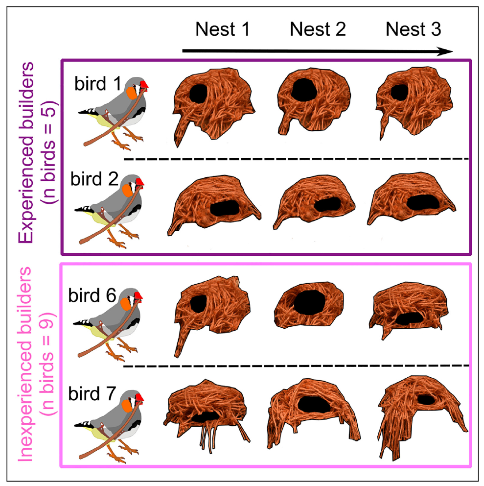

Graphical abstract.

#### Data and Analyses:

Subject data included Pair ID, age, and weight. Data on nest-building behavior included the amount of material used (measured in grams) and the amount of time spent building (measured in days). Digital landmarks of nest photos yielded coordinates that were summarized into variables (nest size, nest shape, entrance size, and entrance shape) through Principal Component Analyses (PCAs). A linear mixed model was used to determine whether experience affects the amount of nest material used by birds. Permutation tests compared the morphological differences between nests built by birds in the Experimental and Control groups.

## Data Analysis & Visualization Replication

#### 1) Effect of experience on use of nest material

**Inferential statistical analysis:**

Methods: The authors described using a linear mixed model from the *R* package `{lme4}` to determine the effect of experience on use of nest material. The response variable was the amount (g) of coconut fiber used per nest, and explanatory variables were prior experience building nests with string, the building attempt number, and the days spent building the nest. The pair ID was included as a random factor because the measures were repeated for each pair. To make sure the model fit the assumptions, they used the `{ggResidpanel}` package. They log-transformed the amount of coconut fiber to fit the assumption of normality.

Results: Zebra finches in the Experimental group were found to use less coconut fiber material compared to birds in the Control group. The results section also reports the SE = 0.136, t = -2.835, and *p* = 0.013.

Replication: Using the model `lmer(data = data, log_Used_Material ~ Experience + Nest_No + Time_Taken + (1|PairID), REML = FALSE)`, there was a significant effect of experience on Used_Material (*p* = 0.0134).

```
## # A tibble: 6 × 86
##   PairID Nest_No Experience Male_Size_Class Female_Size_Class Male_Age_Class
##   <chr>    <dbl> <chr>      <chr>           <chr>             <chr>
## 1 P11          1 No         Under           Over              Under
## 2 P11          2 No         Under           Over              Under
## 3 P11          3 No         Under           Over              Under
## 4 P11          4 No         Under           Over              Under
## 5 P12          1 No         Under           Over              Over
## 6 P12          2 No         Under           Over              Over
## # ℹ 80 more variables: Female_Age_Class <chr>, Time_Taken <dbl>,
## #   Time_Class <chr>, Used_Material <dbl>, Material_Class <chr>,
## #   Entrance_Quad <dbl>, N.SizePC1 <dbl>, N.SizePC2 <dbl>, N.ShapePC1 <dbl>,
## #   N.ShapePC2 <dbl>, N.ShapePC3 <dbl>, E.SizePC1 <dbl>, E.SizePC2 <dbl>,
## #   E.SizePC3 <dbl>, E.ShapePC1 <dbl>, E.ShapePC2 <dbl>, E.ShapePC3 <dbl>,
## #   E.ShapePC4 <dbl>, ...25 <lgl>, ...26 <lgl>, ...27 <lgl>, ...28 <lgl>,
## #   ...29 <lgl>, ...30 <lgl>, ...31 <lgl>, ...32 <lgl>, ...33 <lgl>, …
```

[output not shown]

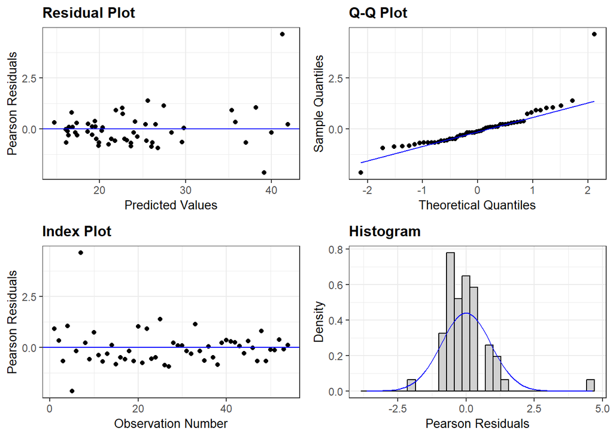

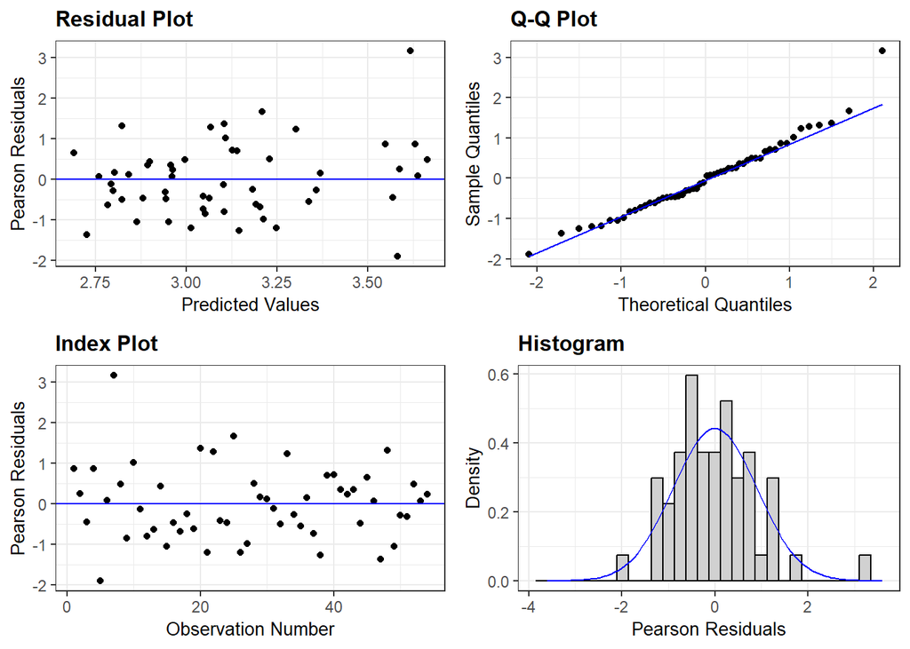

```
## Linear mixed model fit by maximum likelihood . t-tests use Satterthwaite's
##   method [lmerModLmerTest]
## Formula: log_Used_Material ~ Experience + Nest_No + Time_Taken + (1 |
##     PairID)
##    Data: data
##
##      AIC      BIC   logLik deviance df.resid
##     27.4     43.3     -5.7     11.4       46
##
## Scaled residuals:
##     Min      1Q  Median      3Q     Max
## -1.8940 -0.5913 -0.0252  0.4923  3.1632
##
## Random effects:
##  Groups   Name        Variance Std.Dev.
##  PairID   (Intercept) 0.04609  0.2147
##  Residual             0.04858  0.2204
## Number of obs: 54, groups:  PairID, 14
##
## Fixed effects:
##               Estimate Std. Error       df t value Pr(>|t|)
## (Intercept)    3.04445    0.20498 53.68253  14.853   <2e-16 ***
## ExperienceYes -0.38697    0.13775 14.78309  -2.809   0.0134 *
## Nest_No2       0.03976    0.08725 40.45829   0.456   0.6511
## Nest_No3       0.01967    0.08957 40.45700   0.220   0.8273
## Nest_No4       0.03628    0.08334 39.82537   0.435   0.6657
## Time_Taken     0.01506    0.01816 46.86147   0.829   0.4112
## ---
## Signif. codes:  0 '***' 0.001 '**' 0.01 '*' 0.05 '.' 0.1 ' ' 1
##
## Correlation of Fixed Effects:
##             (Intr) ExprnY Nst_N2 Nst_N3 Nst_N4
## ExperiencYs -0.090
## Nest_No2     0.069  0.048
## Nest_No3    -0.015  0.075  0.506
## Nest_No4    -0.176  0.005  0.486  0.471
## Time_Taken  -0.885 -0.162 -0.297 -0.208 -0.031
```

**Data Visualization**

The article includes a boxplot graph showing the effect of experience on use of nest material. The y-axis displays the amount of used material, and the x-axis is the nest order. Data from the Control group are shown in white boxes, labeled *Experience: No*, and data from the Experimental group are shaded in gray and labeled *Experience: Yes*.

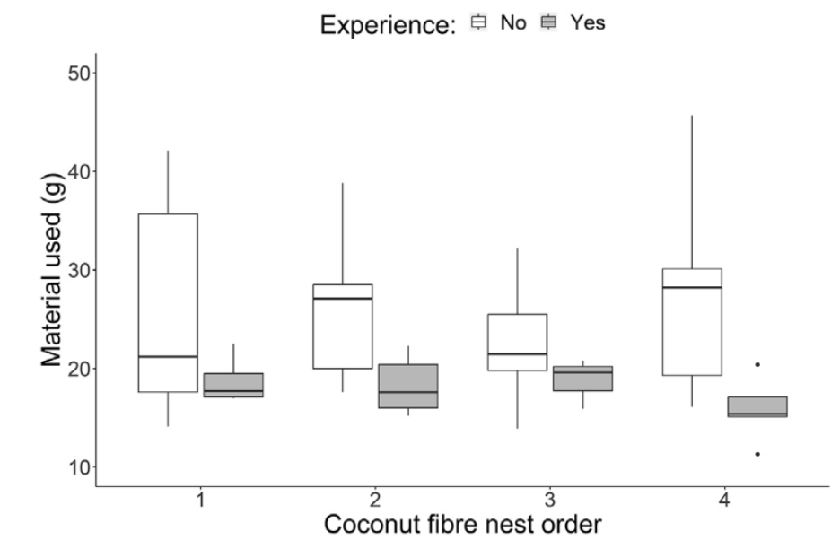

Figure 5. Experienced pairs used less coconut fiber to build nests than inexperienced pairs.

```r
knitr::include_graphics("https://github.com/jennieandbird/data-analysis-replication/blob/main/images/figure5.PNG?raw=true")
```

Replication:

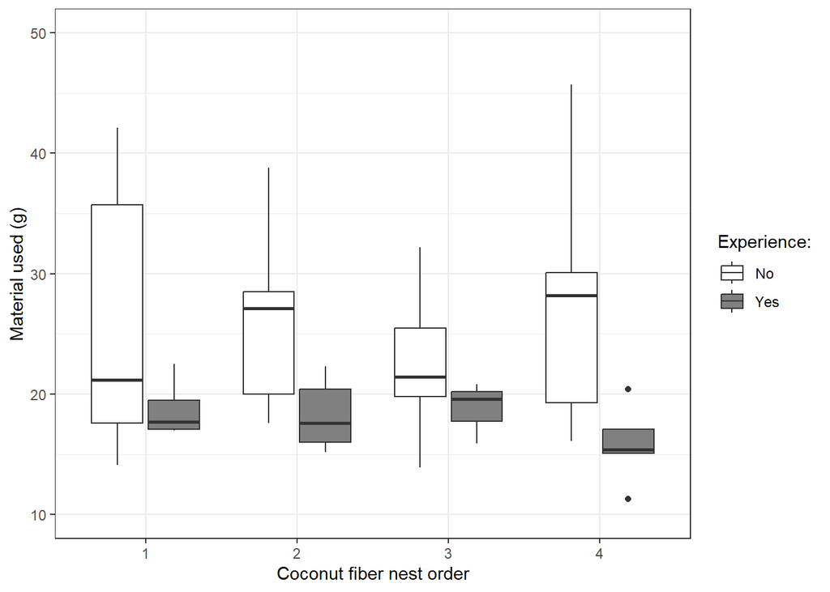

#### 2) Nest morphology

**Descriptive statistics:**

Results: The coconut-fiber nests averaged 18.3 cm long (SD = 3.4 cm), and 20.3 cm wide (SD = 4.9 cm) using the top-down photographs. The front view photos showed nests with height averaging 11.7 cm (SD = 3.7 cm).

Replication: Using `summary(data2)`, the average top-down length and width of nests are 18.32 cm and 20.29 cm, and the average height is 11.729 cm. This matches the results from the article. The `sd()` function gives 3.363328, 4.89693 and 3.690065, also matching the results from the article.

```r
# Load other data set
file2 <- "https://raw.githubusercontent.com/jennieandbird/data-analysis-replication/main/data/data1.csv"
data2 <- read_csv(file2)
head(data2)
```

```
## # A tibble: 6 × 61
##   PairID Experience Nest_No Left.Height Left.Length Right.Height Right.Length
##   <chr>  <chr>        <dbl>       <dbl>       <dbl>        <dbl>        <dbl>
## 1 P11    No               1       12.1         17.5        12.8          17.1
## 2 P11    No               2       12.6         18.4        13.3          16.8
## 3 P11    No               3        9.81        19.3        10.1          19.4
## 4 P11    No               4       11.0         18.0        13.0          19.1
## 5 P12    No               1        7.56        15.4         7.75         15.8
## 6 P12    No               2       12.9         18.5        12.8          17.6
## # ℹ 54 more variables: Front.Height <dbl>, Front.Width <dbl>, Top.Length <dbl>,
## #   Top.Width <dbl>, Entrance.Height <dbl>, Entrance.Width <dbl>,
## #   Above.Entrance <dbl>, Below.Entrance <dbl>, Top.Coord1 <dbl>,
## #   Top.Coord2 <dbl>, Top.Coord3 <dbl>, Top.Coord4 <dbl>, Top.Coord5 <dbl>,
## #   Top.Coord6 <dbl>, Top.Coord7 <dbl>, Top.Coord8 <dbl>, Top.Coord9 <dbl>,
## #   Top.Coord10 <dbl>, Top.Coord11 <dbl>, Top.Coord12 <dbl>, Top.Coord13 <dbl>,
## #   Top.Coord14 <dbl>, Top.Coord15 <dbl>, Top.Coord16 <dbl>, …
```

```r
names(data2)
```

```
##  [1] "PairID"          "Experience"      "Nest_No"         "Left.Height"
##  [5] "Left.Length"     "Right.Height"    "Right.Length"    "Front.Height"
##  [9] "Front.Width"     "Top.Length"      "Top.Width"       "Entrance.Height"
## [13] "Entrance.Width"  "Above.Entrance"  "Below.Entrance"  "Top.Coord1"
## [17] "Top.Coord2"      "Top.Coord3"      "Top.Coord4"      "Top.Coord5"
## [21] "Top.Coord6"      "Top.Coord7"      "Top.Coord8"      "Top.Coord9"
## [25] "Top.Coord10"     "Top.Coord11"     "Top.Coord12"     "Top.Coord13"
## [29] "Top.Coord14"     "Top.Coord15"     "Top.Coord16"     "Top.Coord17"
## [33] "Top.Coord18"     "Top.Coord19"     "Top.Coord20"     "Top.Coord21"
## [37] "Top.Coord22"     "Ent.Coord1"      "Ent.Coord2"      "Ent.Coord3"
## [41] "Ent.Coord4"      "Ent.Coord5"      "Ent.Coord6"      "Ent.Coord7"
## [45] "Ent.Coord8"      "Ent.Coord9"      "Ent.Coord10"     "Ent.Coord11"
## [49] "Ent.Coord12"     "Ent.Coord13"     "Ent.Coord14"     "Ent.Coord15"
## [53] "Ent.Coord16"     "Ent.Coord17"     "Ent.Coord18"     "Ent.Coord19"
## [57] "Ent.Coord20"     "Ent.Coord21"     "Ent.Coord22"     "Ent.Coord23"
## [61] "Ent.Coord24"
```

```r
# The conversion from Excel file to CSV added a lot of "NA" to the bottom; remove those.
data2 <- data2 |>  filter(!is.na(PairID))
# Use summary to quickly get the averages.
summary(data2)
```

```
##     PairID           Experience           Nest_No      Left.Height
##  Length:56          Length:56          Min.   :1.00   Min.   : 6.240
##  Class :character   Class :character   1st Qu.:1.75   1st Qu.: 7.732
##  Mode  :character   Mode  :character   Median :2.50   Median : 8.905
##                                        Mean   :2.50   Mean   : 9.252
##                                        3rd Qu.:3.25   3rd Qu.:10.418
##                                        Max.   :4.00   Max.   :14.400
##
##   Left.Length     Right.Height     Right.Length    Front.Height
##  Min.   :11.71   Min.   : 6.150   Min.   :11.25   Min.   : 5.890
##  1st Qu.:13.38   1st Qu.: 7.505   1st Qu.:13.62   1st Qu.: 9.117
##  Median :14.41   Median : 8.580   Median :14.51   Median :10.700
##  Mean   :15.10   Mean   : 9.136   Mean   :15.01   Mean   :11.729
##  3rd Qu.:16.28   3rd Qu.:10.255   3rd Qu.:16.24   3rd Qu.:13.455
##  Max.   :22.94   Max.   :14.580   Max.   :25.08   Max.   :21.670
##                  NA's   :1        NA's   :1       NA's   :2
##   Front.Width      Top.Length      Top.Width     Entrance.Height
##  Min.   :11.72   Min.   :12.01   Min.   :13.52   Min.   :1.750
##  1st Qu.:14.96   1st Qu.:16.14   1st Qu.:16.45   1st Qu.:2.435
##  Median :16.77   Median :17.31   Median :19.20   Median :2.850
##  Mean   :17.57   Mean   :18.32   Mean   :20.29   Mean   :2.897
##  3rd Qu.:18.61   3rd Qu.:19.70   3rd Qu.:22.26   3rd Qu.:3.305
##  Max.   :32.40   Max.   :27.89   Max.   :35.76   Max.   :4.560
##  NA's   :2       NA's   :4       NA's   :4
##  Entrance.Width  Above.Entrance  Below.Entrance     Top.Coord1
##  Min.   :2.400   Min.   :1.940   Min.   : 0.000   Min.   :-0.4891
##  1st Qu.:3.312   1st Qu.:3.241   1st Qu.: 2.830   1st Qu.:-0.3968
##  Median :3.650   Median :4.145   Median : 4.535   Median :-0.3650
##  Mean   :3.878   Mean   :4.008   Mean   : 5.548   Mean   :-0.3625
##  3rd Qu.:4.412   3rd Qu.:4.720   3rd Qu.: 7.320   3rd Qu.:-0.3238
##  Max.   :6.550   Max.   :7.320   Max.   :20.280   Max.   :-0.2139
##                                                   NA's   :5
##    Top.Coord2        Top.Coord3        Top.Coord4        Top.Coord5
##  Min.   :-0.4593   Min.   :-0.4500   Min.   :-0.3324   Min.   :-0.16866
##  1st Qu.:-0.3769   1st Qu.:-0.3132   1st Qu.:-0.2394   1st Qu.:-0.12906
##  Median :-0.3558   Median :-0.2993   Median :-0.2269   Median :-0.12024
##  Mean   :-0.3529   Mean   :-0.2998   Mean   :-0.2301   Mean   :-0.12031
##  3rd Qu.:-0.3376   3rd Qu.:-0.2809   3rd Qu.:-0.2172   3rd Qu.:-0.11141
##  Max.   :-0.2683   Max.   :-0.2389   Max.   :-0.1754   Max.   :-0.07766
##  NA's   :5         NA's   :5         NA's   :5         NA's   :5
```

[output cut: 73 more lines]

```
##  Min.   :-0.3023   Min.   :-0.22962   Min.   :-0.078377   Min.   :0.06639
##  1st Qu.:-0.2439   1st Qu.:-0.17031   1st Qu.:-0.029845   1st Qu.:0.12292
##  Median :-0.2154   Median :-0.15444   Median :-0.019973   Median :0.13655
##  Mean   :-0.2207   Mean   :-0.15466   Mean   :-0.021109   Mean   :0.13616
##  3rd Qu.:-0.1997   3rd Qu.:-0.13737   3rd Qu.:-0.009943   3rd Qu.:0.15490
##  Max.   :-0.1474   Max.   :-0.07336   Max.   : 0.020665   Max.   :0.17416
##
##   Ent.Coord24
##  Min.   :0.1361
##  1st Qu.:0.2157
##  Median :0.2342
##  Mean   :0.2328
##  3rd Qu.:0.2484
##  Max.   :0.3244
##
```

```r
# Use sd() to get the Standard Deviation; remove NA so it doesn't give an error.
sd(data2$Top.Length, na.rm = TRUE)
```

```
## [1] 3.363328
```

```r
sd(data2$Top.Width, na.rm = TRUE)
```

```
## [1] 4.89693
```

```r
sd(data2$Front.Height, na.rm = TRUE)
```

```
## [1] 3.690065
```

## Discussion & Reflection

Whittaker et al. published data files that were clearly organized and with labels that were easy to understand. Following the methods described in the article, it was plain to see which variable corresponded to, for example, nest length measured from top-down photographs (**Top.Length**) or height measured from front view photos (**Front.Height**). I was able to replicate an example of descriptive statistics and data visualization, but did not have as much luck with my chosen example of inferential statistics.

Using the Methods and Results sections for guidance, I was *almost* able to replicate the results of the linear mixed model. I got the same p-value, but was looking for SE = 0.136 and t = -2.835, but I got SE = 0.138 and t = -2.809. Earlier in the article while listing methods for the PCA, the authors describe how missing values were estimated using the package `{missMDA}`. Maybe if my linear mixed model included some missing values, that could explain why the results were different, but only slightly. Also, there may have been another way that data were filtered which I didn’t replicate correctly. (Whittaker et al. published their code in addition to the data files, so I can figure out what I was missing after turning in this assignment.)